# Name: Aashi Aggarwal Student Id: 8920299 AI LAB-3

### Loading Libraries and Dataset

```python
import pandas as pd
import numpy as np
from scipy import stats
from sklearn.preprocessing import MinMaxScaler
import matplotlib.pyplot as plt
import seaborn as sns
from sklearn.ensemble import RandomForestClassifier
from sklearn.model_selection import cross_validate
from sklearn.linear_model import LogisticRegression
from sklearn.tree import DecisionTreeClassifier
from sklearn.svm import SVC
from sklearn.metrics import accuracy_score
from sklearn.model_selection import train_test_split
from sklearn.metrics import roc_curve, auc
from imblearn.over_sampling import SMOTE as smt
from sklearn.neighbors import KNeighborsClassifier
from sklearn.metrics import accuracy_score, roc_auc_score,precision_score, recall_score, f1_score, confusion_matrix
```

```python
# Load the dataset
data = pd.read_csv('creditcard.csv')
print(len(data))
print(len(data[data["Class"]==1]))
print(len(data[data["Class"]==0]))
```

```
284807
492
284315
```

## **Data Preprocessing Tasks (9 Points)**

### Q2: normalize numerical features using appropriate method based on feature characteristics.

```python
# Initialize the MinMaxScaler
scaler = MinMaxScaler()

# Fit the scaler to the data and transform the numerical features
normalized_features = scaler.fit_transform(data)

# Replace the original numerical features with the normalized ones
data[data.columns] = normalized_features

# Print the first few rows of the normalized dataset
print("Normalized Dataset:")
data
```

```
Normalized Dataset:
```

|  | Time | V1 | V2 | V3 | V4 | V5 | V6 | V7 | V8 | V9 | ... | V21 | V22 | V23 | V24 | V25 | V26 | V27 | V28 | Amount | Class |
| --- | --- | --- | --- | --- | --- | --- | --- | --- | --- | --- | --- | --- | --- | --- | --- | --- | --- | --- | --- | --- | --- |
| 0 | 0.000000 | 0.935192 | 0.766490 | 0.881365 | 0.313023 | 0.763439 | 0.267669 | 0.266815 | 0.786444 | 0.475312 | ... | 0.561184 | 0.522992 | 0.663793 | 0.391253 | 0.585122 | 0.394557 | 0.418976 | 0.312697 | 0.005824 | 0.0 |
| 1 | 0.000000 | 0.978542 | 0.770067 | 0.840298 | 0.271796 | 0.766120 | 0.262192 | 0.264875 | 0.786298 | 0.453981 | ... | 0.557840 | 0.480237 | 0.666938 | 0.336440 | 0.587290 | 0.446013 | 0.416345 | 0.313423 | 0.000105 | 0.0 |
| 2 | 0.000006 | 0.935217 | 0.753118 | 0.868141 | 0.268766 | 0.762329 | 0.281122 | 0.270177 | 0.788042 | 0.410603 | ... | 0.565477 | 0.546030 | 0.678939 | 0.289354 | 0.559515 | 0.402727 | 0.415489 | 0.311911 | 0.014739 | 0.0 |
| 3 | 0.000006 | 0.941878 | 0.765304 | 0.868484 | 0.213661 | 0.765647 | 0.275559 | 0.266803 | 0.789434 | 0.414999 | ... | 0.559734 | 0.510277 | 0.662607 | 0.223826 | 0.614245 | 0.389197 | 0.417669 | 0.314371 | 0.004807 | 0.0 |
| 4 | 0.000012 | 0.938617 | 0.776520 | 0.864251 | 0.269796 | 0.762975 | 0.263984 | 0.268968 | 0.782484 | 0.490950 | ... | 0.561327 | 0.547271 | 0.663392 | 0.401270 | 0.566343 | 0.507497 | 0.420561 | 0.317490 | 0.002724 | 0.0 |
| ... | ... | ... | ... | ... | ... | ... | ... | ... | ... | ... | ... | ... | ... | ... | ... | ... | ... | ... | ... | ... | ... |
| 284802 | 0.999965 | 0.756448 | 0.873531 | 0.666991 | 0.160317 | 0.729603 | 0.236810 | 0.235393 | 0.863749 | 0.528729 | ... | 0.564920 | 0.515249 | 0.680500 | 0.313600 | 0.658558 | 0.466291 | 0.433929 | 0.329840 | 0.000030 | 0.0 |
| 284803 | 0.999971 | 0.945845 | 0.766677 | 0.872678 | 0.219189 | 0.771561 | 0.273661 | 0.265504 | 0.788548 | 0.482925 | ... | 0.564933 | 0.553153 | 0.665619 | 0.245298 | 0.543855 | 0.360884 | 0.417775 | 0.312038 | 0.000965 | 0.0 |
| 284804 | 0.999977 | 0.990905 | 0.764080 | 0.781102 | 0.227202 | 0.783425 | 0.293496 | 0.263547 | 0.792985 | 0.477677 | ... | 0.565220 | 0.537005 | 0.664877 | 0.468492 | 0.592824 | 0.411177 | 0.416593 | 0.312585 | 0.002642 | 0.0 |
| 284805 | 0.999977 | 0.954209 | 0.772856 | 0.849587 | 0.282508 | 0.763172 | 0.269291 | 0.261175 | 0.792671 | 0.476287 | ... | 0.565755 | 0.547353 | 0.663008 | 0.398836 | 0.545958 | 0.514746 | 0.418520 | 0.315245 | 0.000389 | 0.0 |
| 284806 | 1.000000 | 0.949232 | 0.765256 | 0.849601 | 0.229488 | 0.765632 | 0.256488 | 0.274963 | 0.780938 | 0.479528 | ... | 0.565688 | 0.540031 | 0.671029 | 0.383420 | 0.551319 | 0.291786 | 0.416466 | 0.313401 | 0.008446 | 0.0 |

284807 rows × 31 columns

### Q1: Detect and handle outliers for all the numerical features in the dataset using either the Whiskers Approach, or Z-score approach.

```python
# only the "Time" and "Class" columns for outlier detection
columns_to_handle_outliers = ["Time","Amount"]
outlier_data = data[columns_to_handle_outliers]


z_threshold = 3


z_scores = stats.zscore(outlier_data)

outliers = (abs(z_scores) > z_threshold).any(axis=1)

# Remove outliers
filtered_data = data[~outliers]


print(f"Number of outliers detected: {sum(outliers)}")
print("Filtered Dataset:")
print(filtered_data.head())

filtered_data.shape
```

```
Number of outliers detected: 4076
Filtered Dataset:
       Time        V1        V2        V3        V4        V5        V6
0  0.000000  0.935192  0.766490  0.881365  0.313023  0.763439  0.267669  \
1  0.000000  0.978542  0.770067  0.840298  0.271796  0.766120  0.262192
2  0.000006  0.935217  0.753118  0.868141  0.268766  0.762329  0.281122
3  0.000006  0.941878  0.765304  0.868484  0.213661  0.765647  0.275559
4  0.000012  0.938617  0.776520  0.864251  0.269796  0.762975  0.263984

         V7        V8        V9  ...       V21       V22       V23       V24
0  0.266815  0.786444  0.475312  ...  0.561184  0.522992  0.663793  0.391253  \
1  0.264875  0.786298  0.453981  ...  0.557840  0.480237  0.666938  0.336440
2  0.270177  0.788042  0.410603  ...  0.565477  0.546030  0.678939  0.289354
3  0.266803  0.789434  0.414999  ...  0.559734  0.510277  0.662607  0.223826
4  0.268968  0.782484  0.490950  ...  0.561327  0.547271  0.663392  0.401270

        V25       V26       V27       V28    Amount  Class
0  0.585122  0.394557  0.418976  0.312697  0.005824    0.0
1  0.587290  0.446013  0.416345  0.313423  0.000105    0.0
2  0.559515  0.402727  0.415489  0.311911  0.014739    0.0
3  0.614245  0.389197  0.417669  0.314371  0.004807    0.0
4  0.566343  0.507497  0.420561  0.317490  0.002724    0.0

[5 rows x 31 columns]
```

```
(280731, 31)
```

## NOTE: On considering all numerical features for the outlier detection, its completely removing one class and in that case its recommended to either not run outlier detection approach at all or run it on specific columns. As, in the dataset, its mentioned v1 to v28 data is processed with PCA approach already, so I am considering the column Time, Amount to detect outlier.

### **Descriptive Analytics Tasks (10 Points):** Q1: Analyze the distribution of fraud vs non-fraud transactions and comment on it

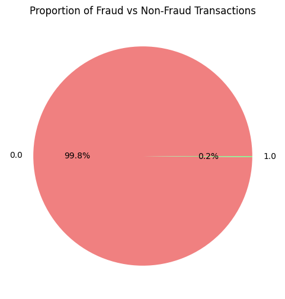

```
Summary Statistics:
Total number of transactions: 284807
Number of non-fraud transactions: 280250
Number of fraud transactions: 481
Percentage of fraud transactions: 0.17%
```

```python
fraud_counts = filtered_data['Class'].value_counts()

# Plot the distribution
plt.figure(figsize=(6, 6))
plt.pie(fraud_counts, labels=fraud_counts.index, autopct='%1.1f%%', colors=['lightcoral', 'lightgreen'])
plt.title('Proportion of Fraud vs Non-Fraud Transactions')
plt.show()

# Print summary statistics
print("Summary Statistics:")
print(f"Total number of transactions: {len(data)}")
print(f"Number of non-fraud transactions: {fraud_counts[0]}")
print(f"Number of fraud transactions: {fraud_counts[1]}")
print(f"Percentage of fraud transactions: {100 * fraud_counts[1] / len(data):.2f}%")
```

### Q2: Analyze the correlation between fraud/non-fraud transactions and all the other numerical features.

```
Time     -0.012323
V1       -0.101347
V2        0.091289
V3       -0.192961
V4        0.133447
V5       -0.094974
V6       -0.043643
V7       -0.187257
V8        0.019875
V9       -0.097733
V10      -0.216883
V11       0.154876
V12      -0.260593
V13      -0.004570
V14      -0.302544
V15      -0.004223
V16      -0.196539
V17      -0.326481
V18      -0.111485
V19       0.034783
V20       0.020090
V21       0.040413
V22       0.000805
V23      -0.002685
V24      -0.007221
V25       0.003308
V26       0.004455
V27       0.017580
V28       0.009536
Amount    0.005632
Name: Class, dtype: float64
```

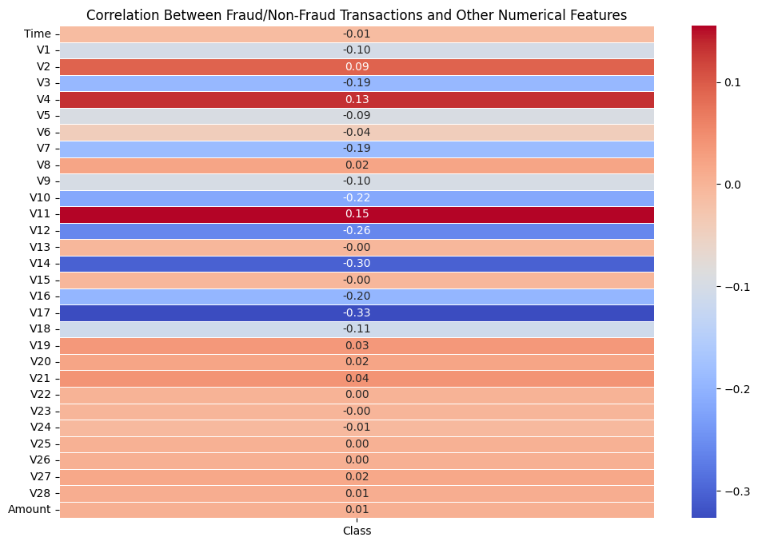

```python
correlation_matrix = data.corr()


fraud_correlation = correlation_matrix['Class'].drop('Class')
print(fraud_correlation)

# Plot a heatmap
plt.figure(figsize=(12, 8))
sns.heatmap(fraud_correlation.to_frame(), annot=True, cmap="coolwarm", fmt=".2f", cbar=True, linewidths=.5)
plt.title('Correlation Between Fraud/Non-Fraud Transactions and Other Numerical Features')
plt.show()

#print(max(fraud_correlation))
```

### Q3: From the previous step, choose the 10 features with highest correlation with the target variable, and plot their distributions against the fraud/non-fraud transactions.

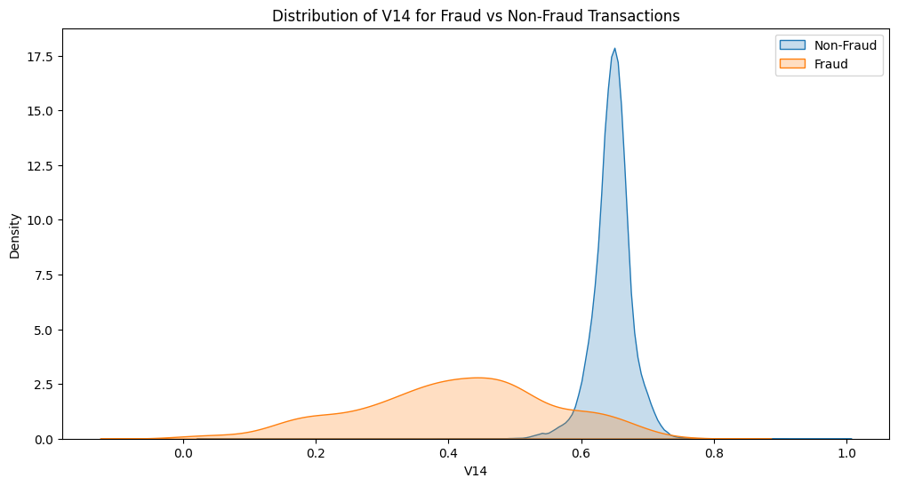

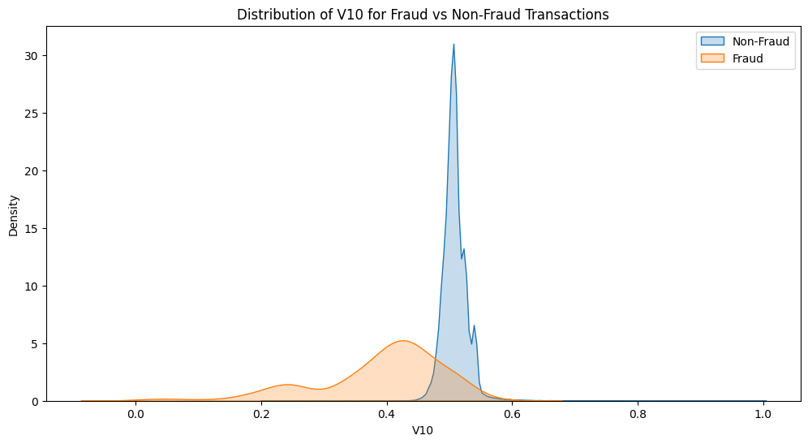

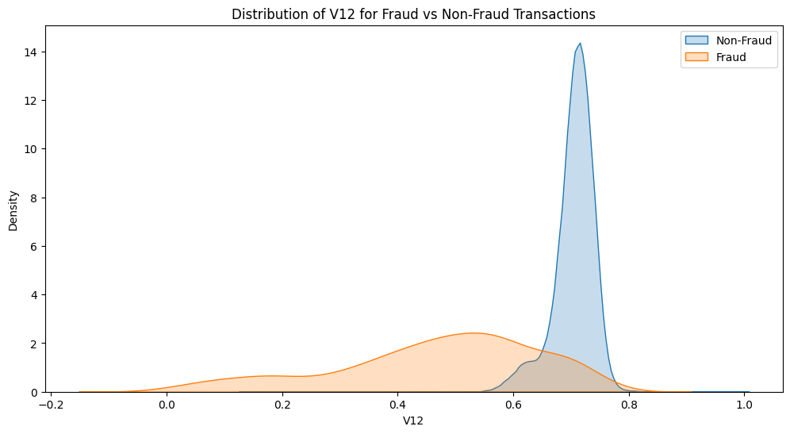

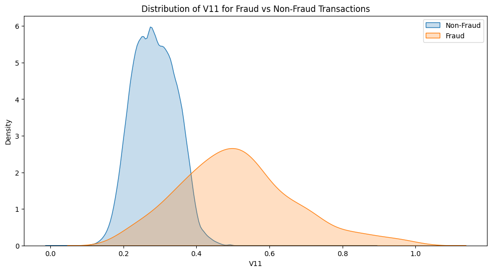

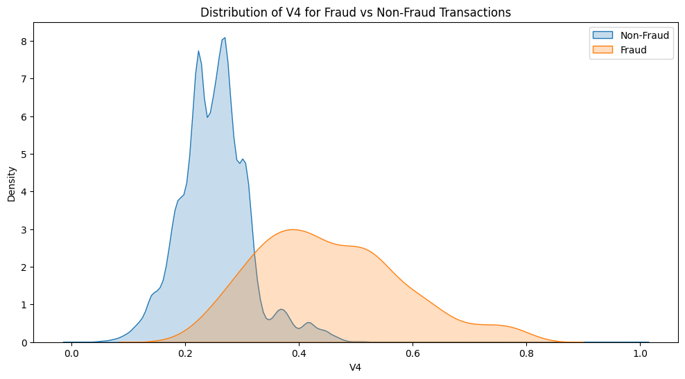

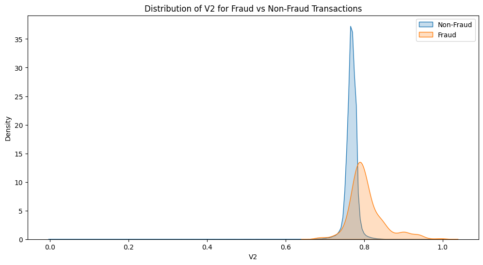

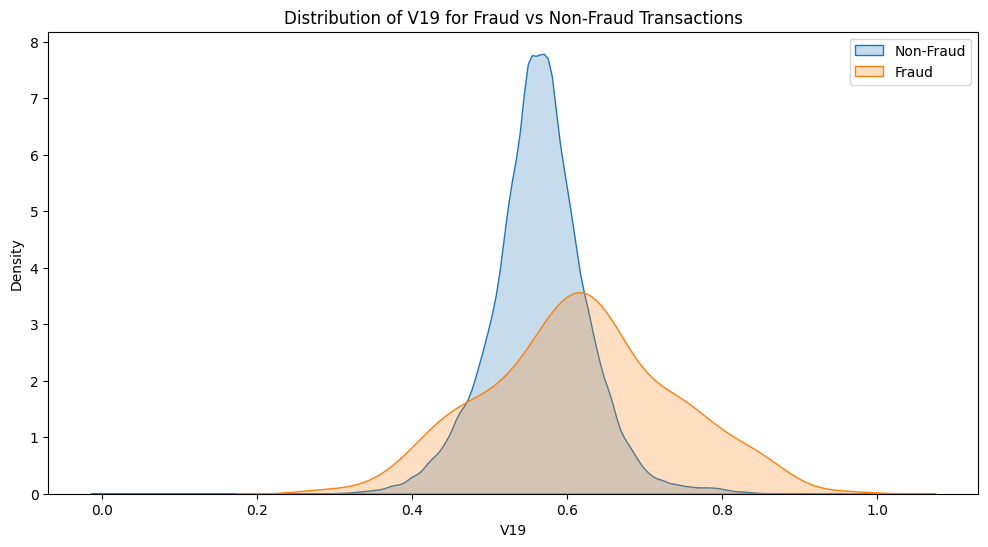

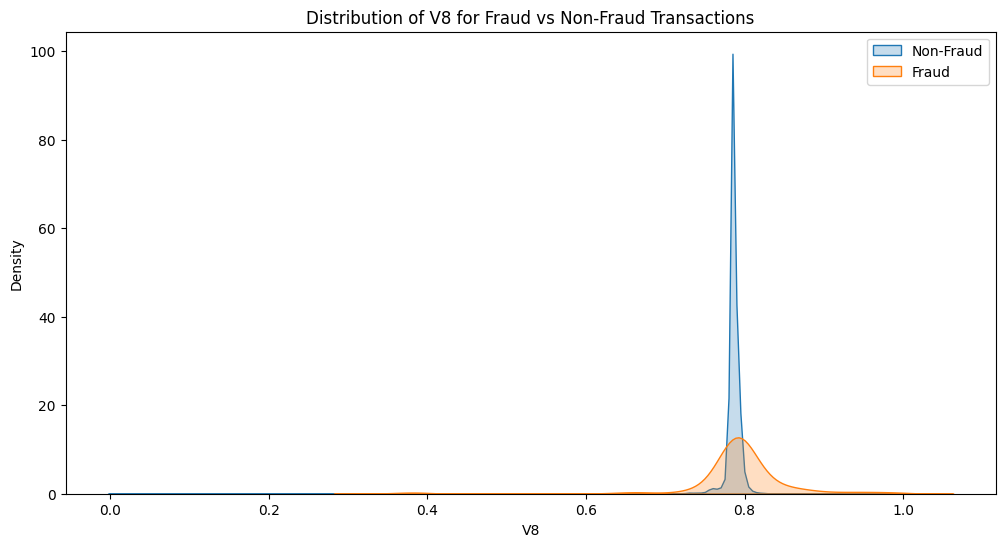

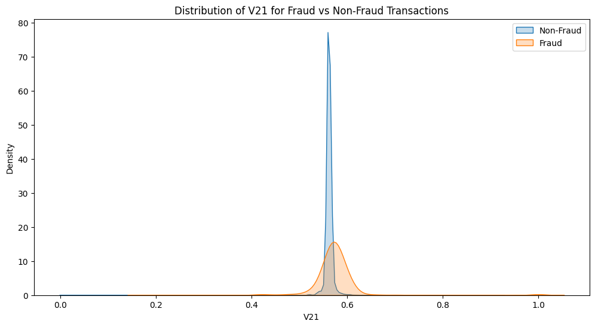

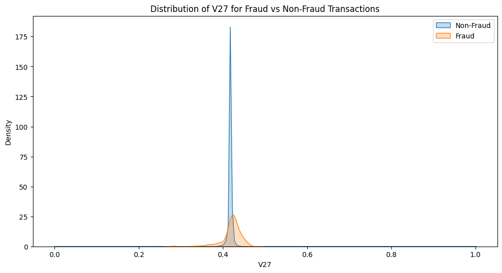

```python
top_features = ['V14', 'V10', 'V12', 'V11', 'V4', 'V2', 'V19', 'V8', 'V21', 'V27']

# Plot the distributin
for feature in top_features:
    plt.figure(figsize=(12, 6))
    sns.kdeplot(data[data['Class'] == 0][feature], label='Non-Fraud', shade=True)
    sns.kdeplot(data[data['Class'] == 1][feature], label='Fraud', shade=True)
    plt.title(f'Distribution of {feature} for Fraud vs Non-Fraud Transactions')
    plt.xlabel(feature)
    plt.ylabel('Density')
    plt.legend()
    plt.show()
```

## **ML Model Training and Testing Tasks (27 Points)**

### Q1: Split the cleaned data into training and testing sets (e.g., 80% training, 20% testing)

```python
X = filtered_data.drop("Class", axis=1)
y = filtered_data["Class"]

# Split the data
X_train, X_test, y_train, y_test = train_test_split(X, y, test_size=0.2, random_state=42)
```

```python
models = {
   # 'Random Forest': RandomForestClassifier(),
    'Logistic Regression': LogisticRegression(),
    'Support Vector Machine': SVC(),
    'Decision Tree': DecisionTreeClassifier()
}

scoring_metrics = ['accuracy', 'precision', 'recall', 'f1']

for model_name, model in models.items():
    results = cross_validate(model, X, y, cv=4, scoring=scoring_metrics)

    print(f"\nModel: {model_name}")
    for metric in scoring_metrics:
        metric_scores = results[f'test_{metric}']
        print(f"{metric.capitalize()} scores: {metric_scores}")
        print(f"Mean {metric.capitalize()}: {metric_scores.mean():.3f}")
```

```
Model: Logistic Regression
Accuracy scores: [0.99913084 0.99878888 0.99931607 0.99868912]
Mean Accuracy: 0.999
Precision scores: [0.71851852 0.97297297 1.         1.        ]
Mean Precision: 0.923
Recall scores: [0.80833333 0.3        0.60330579 0.23333333]
Mean Recall: 0.486
F1 scores: [0.76078431 0.45859873 0.75257732 0.37837838]
Mean F1: 0.588

Model: Support Vector Machine
Accuracy scores: [0.9991166  0.99954405 0.99940156 0.9994443 ]
Mean Accuracy: 0.999
Precision scores: [0.69078947 0.94897959 0.84347826 0.98795181]
Mean Precision: 0.868
Recall scores: [0.875      0.775      0.80165289 0.68333333]
Mean Recall: 0.784
F1 scores: [0.77205882 0.85321101 0.8220339  0.80788177]
Mean F1: 0.814

Model: Decision Tree
Accuracy scores: [0.02063178 0.99937307 0.99790548 0.9989741 ]
Mean Accuracy: 0.754
Precision scores: [0.0016849  0.91304348 0.435      0.71428571]
Mean Precision: 0.516
Recall scores: [0.96666667 0.7        0.71900826 0.66666667]
Mean Recall: 0.763
F1 scores: [0.00336393 0.79245283 0.54205607 0.68965517]
Mean F1: 0.507
```

### Note: #RandomForest was taking more than half an hour to run. So I have commented it.

### Q3: Train a logistic regression model as a baseline model. Q4: Print the learned coefficients (weights) of the model. Comment on which feature the model gave higher weight to in the weight vector. Q5: Evaluate the model's performance on the test set using the following metrics: a. Accuracy b. Precision c. Recall d. F1-Score

```python
logistic_model = LogisticRegression(random_state=42)
logistic_model.fit(X_train, y_train)


coefficients = logistic_model.coef_[0]
feature_names = X.columns

coefficients_df = pd.DataFrame({'Feature': feature_names, 'Coefficient': coefficients})

print(coefficients_df.sort_values(by='Coefficient', ascending=False))


y_pred = logistic_model.predict(X_test)

# Evaluate the model
accuracy = accuracy_score(y_test, y_pred)
precision = precision_score(y_test, y_pred)
recall = recall_score(y_test, y_pred)
f1 = f1_score(y_test, y_pred)
conf_matrix = confusion_matrix(y_test, y_pred)

# Print evaluation metrics
print("\nEvaluation Metrics:")
print("Accuracy:", accuracy)
print("Precision:", precision)
print("Recall:", recall)
print("F1 Score:", f1)
print("\nConfusion Matrix:")
print(conf_matrix)
```

```
   Feature  Coefficient
4       V4     7.830298
11     V11     5.610448
21     V21     0.944789
22     V22     0.819610
5       V5     0.680329
26     V26     0.618621
0     Time     0.597535
29  Amount     0.385219
19     V19     0.171828
2       V2     0.055440
27     V27     0.048721
28     V28     0.030191
20     V20    -0.014230
15     V15    -0.089568
```

[output cut: 26 more lines]

### Q6: Plot the ROC Curve and print the AUC of the model on the test set. Comment on the quality of the model performance as seen in the ROC curve

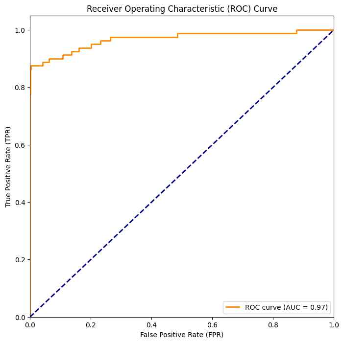

```
AUC: 0.9676949007437531
```

```python
y_prob = logistic_model.predict_proba(X_test)[:, 1]

fpr, tpr, thresholds = roc_curve(y_test, y_prob)

auc_value = auc(fpr, tpr)

# Plot the ROC curve
plt.figure(figsize=(8, 8))
plt.plot(fpr, tpr, color='darkorange', lw=2, label='ROC curve (AUC = {:.2f})'.format(auc_value))
plt.plot([0, 1], [0, 1], color='navy', lw=2, linestyle='--')
plt.xlim([0.0, 1.0])
plt.ylim([0.0, 1.05])
plt.xlabel('False Positive Rate (FPR)')
plt.ylabel('True Positive Rate (TPR)')
plt.title('Receiver Operating Characteristic (ROC) Curve')
plt.legend(loc='lower right')
plt.show()


print("AUC:", auc_value)
```

### Q7: Apply a well-known technique to handle class imbalance and compare the model performance on the test set with and without this approach. Comment on your outcome.

```python
X_resampled, y_resampled = smt(random_state=42).fit_resample(X_train, y_train)

logistic_model = LogisticRegression(random_state=42)
logistic_model.fit(X_resampled, y_resampled)

y_pred = logistic_model.predict(X_test)


evaluation_metrics = {
    'Accuracy': accuracy_score,
    'Precision': precision_score,
    'Recall': recall_score,
    'F1 Score': f1_score,
    'ROC AUC': roc_auc_score
}


print("\nEvaluation Metrics:")
for metric_name, metric_func in evaluation_metrics.items():
    metric_value = metric_func(y_test, y_pred)
    print(f"{metric_name}: {metric_value}")

print("\nConfusion Matrix:")
print(confusion_matrix(y_test, y_pred))
```

[output not shown]

### Q8: Try the KNN and SVM classification compare their performance to the logistic regression baseline.

```python
#K-Nearest Neighbors (KNN) model
knn_model = KNeighborsClassifier()
knn_model.fit(X_train, y_train)

#Support Vector Machine (SVM) model
svm_model = SVC(probability=True, random_state=42)
svm_model.fit(X_train, y_train)

models = {
    'Logistic Regression': logistic_model,
    'K-Nearest Neighbors (KNN)': knn_model,
    'Support Vector Machine (SVM)': svm_model
}

for model_name, model in models.items():
    y_pred = model.predict(X_test)
    y_prob = model.predict_proba(X_test)[:, 1]

    print(f"\nEvaluation Metrics for {model_name}:")
    print("Accuracy:", accuracy_score(y_test, y_pred))
    print("Precision:", precision_score(y_test, y_pred))
    print("Recall:", recall_score(y_test, y_pred))
    print("F1 Score:", f1_score(y_test, y_pred))
    print("ROC AUC:", roc_auc_score(y_test, y_prob))
    print("Confusion Matrix:")
    print(confusion_matrix(y_test, y_pred))
```

```
Evaluation Metrics for Logistic Regression:
Accuracy: 0.9788056352075801
Precision: 0.056
Recall: 0.875
F1 Score: 0.10526315789473684
ROC AUC: 0.9799394028572959
Confusion Matrix:
[[54887  1180]
 [   10    70]]

Evaluation Metrics for K-Nearest Neighbors (KNN):
Accuracy: 0.9995369298448715
Precision: 0.9090909090909091
Recall: 0.75
F1 Score: 0.821917808219178
ROC AUC: 0.91239811297198
Confusion Matrix:
[[56061     6]
 [   20    60]]

Evaluation Metrics for Support Vector Machine (SVM):
Accuracy: 0.9993588259390529
Precision: 0.7619047619047619
Recall: 0.8
F1 Score: 0.7804878048780488
ROC AUC: 0.9600712094458416
Confusion Matrix:
[[56047    20]
 [   16    64]]
```